# Visualising spatial data in R

David Jogensen

## Spatial data in R

R can act as a fast, free, user friendly graphical information system (GIS) but some work is required to get used to dealing with spatial data in R. The two main types of spatial data you will encounter are raster data (usually high resolution images) and vector data (points, lines and polygons). This tutorial will focus on vector data as this is the more common format for data input, with rasters usually produced as an output from previous analysis.

The `rgdal` package is important for reading and transforming vector data in R, it acts as an interface with the C spatial data processing library gdal from within R. WHO geodatabases have been downloaded from http://hub.arcgis.com/ where they are publicly available. Copy these to your computer and set your working directory to the file you have copied them to. The admin 1 and 2 datasets have been converted to .RData format using R, this is an efficient data storage system in R which allows you to save and load objects in your environment to use in the future or share with others. We will import the disputed areas from an ESRI Shapefile to show you how to use the `readOGR` function

```r
require(rgdal)
# input shapefiles
DISPUTED_AREAS <- readOGR(dsn = "./DISPUTED_AREAS/DISPUTED_AREAS.shp")
load("./GLOBAL_ADM1.Rdata")
load("./ADM_2_PK.RData")
```

The readOGR command above uses only the `dsn` arguement which stands for data source name. When importing full geodatabases with multiple layers (for example the WHO also provides map files in a .gdb format with all admin levels together) the `layer` arguement can be used to select which layer to extract in to the R data environment.

Plot GLOBAL_ADM1 with the `plot` command in R. As you can see, the map covers the whole world, we want to extract only Pakistan from the `GLOBAL_ADM1` file, and only Jammu and Kashmir from the `DISPUTED_AREAS`. As districts and provinces have been renamed over time we also need to make sure we only extract the current borders for each region. We do this by making sure the end date given in the file is later than today’s date using `Sys.Date` in R. Try running `Sys.Date()` in your console and it should return today’s date. The following commands extract Afghanistan from the `GLOBAL_ADM1` data and Kashmir from the `DISPUTED_AREAS`. Write your own code to extract Pakistan from the `GLOBAL_ADM1` data (hint: ISO2 code for Pakistan is PK):

```r
ADM_1_AF <- GLOBAL_ADM1[GLOBAL_ADM1@data$ISO_2_CODE=="AF" & as.Date(GLOBAL_ADM1@data$ENDDATE)>=Sys.Date(),]

JK <- DISPUTED_AREAS[DISPUTED_AREAS@data$NAME=="Jammu and Kashmir",]

ADM_1_PK <-
```

```r
ADM_1_PK <- GLOBAL_ADM1[GLOBAL_ADM1@data$ISO_2_CODE=="PK"
                        & as.Date(GLOBAL_ADM1@data$ENDDATE)>=Sys.Date(),]

JK <- DISPUTED_AREAS[DISPUTED_AREAS@data$NAME=="Jammu and Kashmir",]
```

Remove the `ADM_1_AF` dataset from your environment. For the Admin 2 level data Pakistan has already been extracted for you.

You may notice some notation in the code above which you have not seen before. As spatial data includes point or polygon data alongside a data table, these are stored separately within the data object. Run `View(ADM_2_PK)` in your console, you should see a number of different slots within the object which can be accessed using the @ symbol The key slots for plotting and ammending the data are the `@data` slot which contains an attribute data table for each region in the shapefile and the `@polygons` slot which contains the data needed to plot the boundaries. To access columns within the `@data` table we can then use the dollar operator as you have seen previously. For example `ADM_1_PK@data$ADM1_NAME` should return the names of all the provinces in Pakistan:

```r
ADM_1_PK@data$ADM1_NAME
```

```
## [1] AJK              BALOCHISTAN      GILGIT BALTISTAN ISLAMABAD
## [5] PUNJAB           SINDH            FATA             KHYBER PAKHTOON
## 3139 Levels: Å UMADIJSKI UPRAVNI OKRUG A&N ISLANDS Ä°MIÅžLI ... ZURRIEQ
```

Plotting only a portion of the map is as simple as subsetting any other data frame. The code below plots districts in Sindh only:

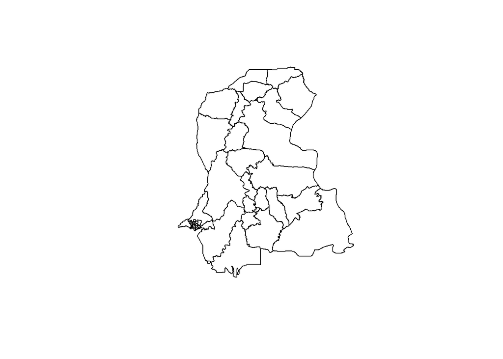

```r
plot(ADM_2_PK[ADM_2_PK$ADM1_NAME=="SINDH",])
```

Try plotting only the Islamabad Capital territory, check in the `ADM_2_PK@data` with the `View` function to see what the capital territory is named in the map file, it is included within Islamabad province. Your output should look like the one below:

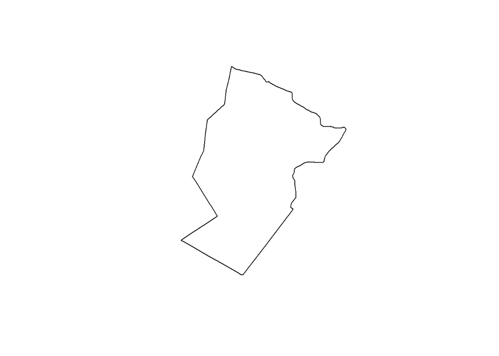

```r
plot(ADM_2_PK[ADM_2_PK$ADM2_NAME=="ICT",])
```

If we want to colour certain districts to highlight them this can be carried out in plot using the same subsetting process. Using the `plot` function, if we want to add a layer to an existing map we need to write an additional plot command with `add=TRUE`:

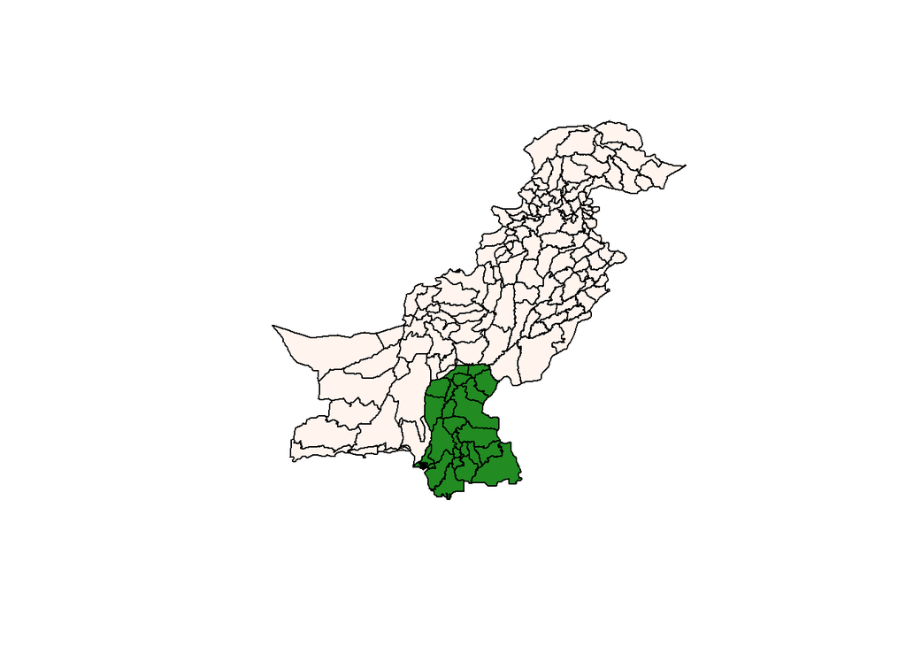

```r
plot(ADM_2_PK, col="seashell")
plot(ADM_2_PK[ADM_2_PK$ADM1_NAME=="SINDH",], col="forestgreen", add=TRUE)
```

This plot uses pre-programmed colours in R, full lists with the colurs shown can be found online by searching “colour in R”. To see the names of all the colours programmed in R run `colors()` in your console.

Try plotting Jammu and Kashmir on this map with the colour `lightgrey`, you will see that this covers up the districts in G-B and AJK. using the `plot` function it is not possible to add this layer behind the existing layers, if you try plotting JK first you will see that this limits the extent of the plot and most of the country is cut off. To go further with mapping we will use ggplot2!

```r
# Adding JK to the existing plot
plot(ADM_2_PK, col="seashell")
plot(ADM_2_PK[ADM_2_PK$ADM1_NAME=="SINDH",], col="forestgreen", add=TRUE)
plot(JK, col="lightgrey", add=TRUE)

# trying to plot JK first
plot(JK, col="lightgrey")
plot(ADM_2_PK, col="seashell", add=TRUE)
plot(ADM_2_PK[ADM_2_PK$ADM1_NAME=="SINDH",], col="forestgreen", add=TRUE)
```